# INFO284 Semester assignment

## Imports

```python
import os
import re
import numpy as np
import pandas as pd
import matplotlib.pyplot as plt

from sklearn.model_selection import train_test_split
from sklearn.preprocessing import StandardScaler, LabelEncoder
from sklearn.utils.class_weight import compute_class_weight
from sklearn.feature_extraction.text import CountVectorizer, TfidfVectorizer
from sklearn.svm import LinearSVC

from sklearn.linear_model import LogisticRegression, LinearRegression
from sklearn.naive_bayes import MultinomialNB
from sklearn.ensemble import RandomForestClassifier

from sklearn.metrics import (
    accuracy_score,
    classification_report,
    confusion_matrix,
    mean_squared_error,
    mean_absolute_error,
    r2_score
)

import tensorflow as tf
from tensorflow import keras

from tensorflow.keras import layers, models
from tensorflow.keras.preprocessing.text import Tokenizer
from tensorflow.keras.preprocessing.sequence import pad_sequences
from tensorflow.keras.models import Sequential
from tensorflow.keras.layers import Embedding, LSTM, Dense, Dropout
from tensorflow.keras.preprocessing import image
from tensorflow.keras.utils import image_dataset_from_directory
from tensorflow.keras.layers import RandomFlip, RandomRotation, RandomZoom
from tensorflow.keras.callbacks import EarlyStopping, ReduceLROnPlateau

from tensorflow.keras.applications import ResNet50, MobileNetV2, EfficientNetB0
from tensorflow.keras.applications.resnet50 import preprocess_input as resnet_preprocess
from tensorflow.keras.applications.mobilenet_v2 import preprocess_input as mobilenet_preprocess
from tensorflow.keras.applications.efficientnet import preprocess_input as efficientnet_preprocess
```

## Task 1

This project aims to develop machine learning models that predict review ratings based on textual content. Exploratory data analysis and preprocessing are performed to understand and prepare the dataset, including necessary data cleaning and feature engineering. Four models are implemented, including one neural network, to compare different approaches and evaluate their strengths and limitations. Model performance is assessed using appropriate metrics, with a focus on generalization to unseen data and the factors influencing performance.

### 1.1 Retrieving the Dataset

```python
df_original = pd.read_csv("reviews.csv")
df = df_original.copy()
df.head()
```

|  | review_id | rating | review_text | review_date | helpful |
| --- | --- | --- | --- | --- | --- |
| 0 | 981e465b-d3ba-4632-9c60-25051efac38a | 5 | It's good | 11/22/2025 1:19 | 0 |
| 1 | 964d3555-9429-4c20-8127-ce3c71ce9273 | 5 | WhatsApp not working well always shows offline... | 11/24/2025 20:03 | 0 |
| 2 | 6c28859f-1554-4ca1-9aa8-9d66f204be0a | 5 | Oppo not corresponding, share with me the offi... | 11/25/2025 6:26 | 0 |
| 3 | a7efafc3-5871-4020-a398-9cc12cb4072a | 5 | Excellent app, great communication super conne... | 11/25/2025 18:09 | 0 |
| 4 | de142b31-a5ad-446f-b7c8-51b264728478 | 4 | simply the ɓest for chat and calls.i love it | 11/24/2025 1:10 | 1 |

We loaded the dataset from a CSV file using pandas, and a copy was created to preserve the original data.

### 1.2 Data Analysis

#### Rating Distribution

The dataset consists of user reviews, where rating is used as the target variable.

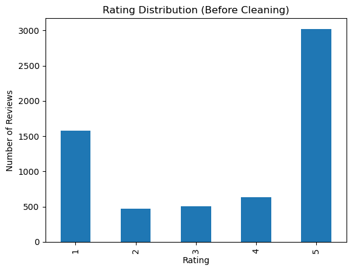

```python
# Visualizes the distribution of ratings in the dataset before preprocessing
rating_counts = df["rating"].value_counts().sort_index()

plt.figure()
rating_counts.plot(kind="bar")

plt.xlabel("Rating")
plt.ylabel("Number of Reviews")
plt.title("Rating Distribution (Before Cleaning)")
plt.show()
```

The distribution of the rating variable was examined to assess class balance. The results show a clear imbalance, with ratings 1 and 5 dominating the dataset. This imbalance may negatively affect model performance, as models can become biased toward the majority classes. Therefore, techniques such as class weighting and the use of evaluation metrics beyond accuracy (e.g., precision, recall, and F1-score) should be considered. This is because class weighting assigns higher importance to underrepresented classes during training, helping the model learn their patterns more effectively. In addition, accuracy alone can be misleading in imbalanced datasets, as a model may achieve high accuracy by simply predicting the majority class. Metrics such as precision, recall, and F1-score provide a more comprehensive evaluation by accounting for performance across all classes, especially the minority ones.

In addition, reformulating the problem as a binary classification task can be considered as a potential solution, as it may reduce complexity and improve overall model performance.

#### Text Length Distribution

By analyzing the distribution of review lengths, we can gain insight into the variability of the textual data. This can help us understand whether the dataset contains extremely short or extremely long reviews.

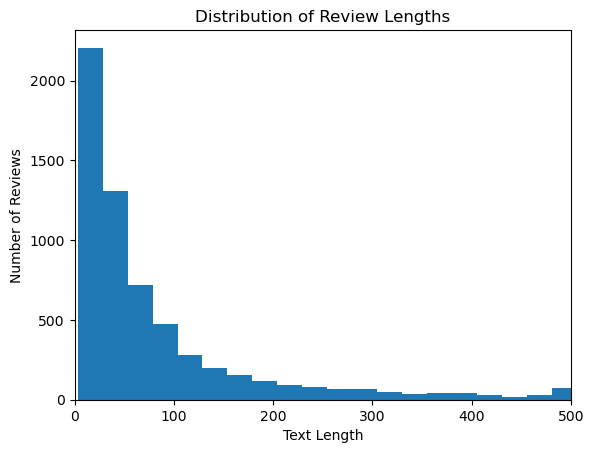

```python
# Visualizes the distribution of review text lengths to understand data characteristics
df["text_length"] = df["review_text"].apply(len)

plt.figure()
plt.hist(df["text_length"], bins=50) #Divides the data into 50 bins for a more detailed view of the distribution
plt.xlabel("Text Length")
plt.ylabel("Number of Reviews")
plt.title("Distribution of Review Lengths")
plt.xlim(0, 500) # Focus on 0–500 range, ignore outliers
plt.show()
```

The distribution is right-skewed, indicating that most reviews are relatively short, while a smaller number are significantly longer. This variation in text length may influence model performance, as longer reviews can contain more information and potentially dominate feature representations. Therefore, text length should be considered during preprocessing. Possible approaches include applying padding for neural network models to ensure equal input length, truncating longer sequences to a fixed maximum length, and using techniques such as TF-IDF to reduce the impact of varying text lengths.

#### Correlation Matrix

We will use a correlation matrix to examine relationships between variables and identify patterns in the data. Additionally, it can show which features may be relevant for predicting the target variable.

```
            rating  helpful  word_count  excl_count
rating        1.00     0.01       -0.26       -0.08
helpful       0.01     1.00        0.04       -0.00
word_count   -0.26     0.04        1.00        0.11
excl_count   -0.08    -0.00        0.11        1.00
```

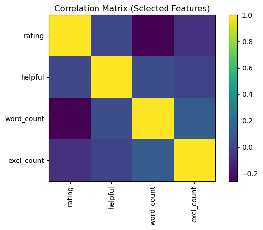

```python
# Text features (simplified)
df["word_count"] = df["review_text"].str.split().str.len()
df["excl_count"] = df["review_text"].str.count("!")

# Correlation matrix
corr = df[[
    "rating",
    "helpful",
    "word_count",
    "excl_count"
]].corr()

print(corr.round(2))

# Visualization
plt.imshow(corr)
plt.colorbar()
plt.xticks(range(len(corr.columns)), corr.columns, rotation=90) #Rotates axis labels vertically to improve readability.
plt.yticks(range(len(corr.index)), corr.index)
plt.title("Correlation Matrix (Selected Features)")
plt.tight_layout()
plt.show()
```

The correlation matrix reveals weak relationships between the numerical features and the target variable, suggesting that these features alone may not be sufficient for accurate prediction. This indicates that additional information, such as textual features, could be important for the classification task.

#### Helpful Analysis

```python
# Top values (counts)
print("Top helpful values (counts):")
print(df["helpful"].value_counts().head(10))  # Show top 10 most frequent values for overview
print()

# Top values (proportions)
print("Top helpful values (proportions):")
print(df["helpful"].value_counts(normalize=True).head(10))
print()

# Key insight: 0 vs >0
zero_share = (df["helpful"] == 0).mean()
nonzero_share = (df["helpful"] > 0).mean()

print("Share of reviews with 0 helpful votes:", round(zero_share, 3))
print("Share of reviews with >0 helpful votes:", round(nonzero_share, 3))
print()

# Summary stats
print("Summary statistics:")
print(df["helpful"].describe())
```

```
Top helpful values (counts):
helpful
0     4939
1      987
2      127
3       34
5       12
6       12
4       12
8        7
12       6
9        6
Name: count, dtype: int64

Top helpful values (proportions):
helpful
0     0.795330
1     0.158937
2     0.020451
3     0.005475
5     0.001932
6     0.001932
4     0.001932
8     0.001127
12    0.000966
9     0.000966
Name: proportion, dtype: float64

Share of reviews with 0 helpful votes: 0.795
Share of reviews with >0 helpful votes: 0.205

Summary statistics:
count      6210.000000
mean         43.463607
std        3161.807086
min           0.000000
25%           0.000000
50%           0.000000
75%           0.000000
max      248962.000000
Name: helpful, dtype: float64
```

Due to its highly skewed distribution and limited variation, the helpful feature was considered less informative. Therefore, it will be excluded during the feature engineering phase.

### 1.3 Feature Engineering and Preprocessing

#### Feature Engineering

By removing irrelevant features, we aim to ensure that the model focuses on the most informative inputs, particularly the textual content of the reviews. In this step, we will remove variables that do not contribute meaningful information to the prediction task. Removing original features such as review_id, helpful, and review_date, as well as engineered features like word_count, excl_count, and text_length. Although some of these features were initially considered relevant, exploratory analysis showed weak relationships with the target variable.

```python
# .drop() removes irrelevant features not needed for the model
df = df.drop(columns=["review_id", "review_date", "helpful", "word_count", "excl_count", "text_length"])
df.head()
```

|  | rating | review_text |
| --- | --- | --- |
| 0 | 5 | It's good |
| 1 | 5 | WhatsApp not working well always shows offline... |
| 2 | 5 | Oppo not corresponding, share with me the offi... |
| 3 | 5 | Excellent app, great communication super conne... |
| 4 | 4 | simply the ɓest for chat and calls.i love it |

#### Data Cleaning

The data cleaning process focuses on removing noisy or uninformative reviews before training the models. We plan to clean the data using the following steps:

- Remove unusally long tokens, because they are unlikely to represent meaningful natural language.
- Remove repeated conductive words, because it often indicates spam or noise.
- Remove empty reviews, because they do not contain useful information.

We also want to apply basic text normalization, to ensure a consistent representation of the text.

```python
df_clean = df.copy()

print("Original number of reviews:", len(df_clean))


#  Removes reviews with long words
df_clean = df_clean[
    ~df_clean["review_text"].str.split().apply(
        lambda words: any(len(word) > 15 for word in words)
    )
]

print("After removing long words:", len(df_clean))


# Regex pattern for 3+ repeated consecutive words,
# removes repeating words (spam)
pattern = r'\b(\w+)\b(?=\s+\1\b\s+\1\b)'

mask = df_clean["review_text"].str.contains(pattern, case=False, regex=True, na=False)
df_clean = df_clean[~mask]

print("After removing repeated words:", len(df_clean))


# Basic text cleaning
def clean_text(text):
    text = text.lower()
    text = re.sub(r"\d+", "", text)
    text = re.sub(r"[^\w\s]", "", text)
    text = re.sub(r"\s+", " ", text).strip()
    return text

df_clean["review_text"] = df_clean["review_text"].apply(clean_text)


# Remove empty reviews
df_clean = df_clean[df_clean["review_text"].str.strip() != ""]

print("After text cleaning:", len(df_clean))


print("\nCLEANING SUMMARY")
print("Original:", len(df))
print("Final:", len(df_clean))
print("Total removed:", len(df) - len(df_clean))

df = df_clean
```

```
Original number of reviews: 6210
After removing long words: 5713
After removing repeated words: 5528
After text cleaning: 5527

CLEANING SUMMARY
Original: 6210
Final: 5527
Total removed: 683
```

#### Additional Preprocessing Techniques

While additional preprocessing techniques such as stemming or lemmatization could be applied, they were not included in this project to avoid removing potentially useful semantic information.

### 1.4 Machine Learning Models

We have considered multiple traditional machine learning models alongside the neural network model. The traditional models we chose were Multinomial Naïve Bayes that is a probabilistic model suited for word-count features. It is simple, fast, and effective for text data. Logistic Regression was chosen as it is a linear model for binary classification that works well with high-dimensional text features and provides interpretable results. Linear Support Vector Machineis is a margin-based classifier that is well-suited for our high-dimensional text dataset, as it can effectively separate classes and generalize well to new data.

For our neural network we chose Long Short-Term Memory that is designed for sequential data, capable of capturing word order and contextual dependencies in text. By using tokenization and embeddings, it enables learning from word order and semantic relationships within reviews. A sequence-based representation using tokenization, truncation and padding will be applied.

Together these models represent different approaches. Traditional models provide strong baselines for text classification, while LSTM captures deeper contextual information, enabling a more comprehensive comparison of model performance on the dataset.

#### Conversion to Binary Classification

As shown earlier, the dataset is imbalanced, with a large proportion of reviews assigned to the highest rating. One potential solution, as mentioned earlier, is to convert the problem from a five-class classification task to a binary classification task, as this may reduce the impact of class imbalance. To evaluate this hypothesis, we compare the performance of the same model trained on the original five-class labels and on the binary labels. This comparison is conducted using an LSTM model to assess whether such a transformation leads to improved performance. While the experiment is limited to this model, the findings may provide an indication of whether similar effects could be expected for other models.

LSTM is used to capture sequential patterns and contextual dependencies in text that traditional linear models cannot represent. By using tokenization and embeddings, it enables learning from word order and semantic relationshups within reviews. A sequence-based representation using tokenization, truncation and padding will be applied.

We chose to convert the ratings into a binary setup by grouping ratings 1–3 as negative and 4–5 as positive. This decision is motivated by the strong class imbalance in the dataset, where a large proportion of reviews belonged to rating 5.

#### Model 1: Long Short Term Memory

##### LSTM Model with Five-Class Classification

```python
# Based on code from GeeksforGeeks
# https://www.geeksforgeeks.org/deep-learning/long-short-term-memory-lstm-rnn-in-tensorflow/

# Uses review text as input and shifts ratings from 1–5 to 0–4
X_multi = df["review_text"]
y_multi = df["rating"] - 1

X_train_multi, X_test_multi, y_train_multi, y_test_multi = train_test_split(
    X_multi,
    y_multi,
    test_size=0.2,   # 20% test data
    random_state=42,  # fixed split (reproducibility)
    stratify=y_multi
)


# Train / validation / test split
X_train_text_multi, X_val_text_multi, y_train_final_multi, y_val_multi = train_test_split(
    X_train_multi,
    y_train_multi,
    test_size=0.2,
    random_state=42,
    stratify=y_train_multi
)


# Tokenization and padding
vocab_size_multi = 20000 # max number of words kept
max_len_multi = 200 # max sequence length
oov_token_multi = "<OOV>" # unknown words token

tokenizer_multi = Tokenizer(
    num_words=vocab_size_multi,
    oov_token=oov_token_multi,
    lower=True
)

tokenizer_multi.fit_on_texts(X_train_text_multi) # build vocabulary from training data only

X_train_seq_multi = tokenizer_multi.texts_to_sequences(X_train_text_multi)
X_val_seq_multi = tokenizer_multi.texts_to_sequences(X_val_text_multi)
X_test_seq_multi = tokenizer_multi.texts_to_sequences(X_test_multi)

X_train_pad_multi = pad_sequences(
    X_train_seq_multi, maxlen=max_len_multi, padding="post", truncating="post" # ensure equal length
)
X_val_pad_multi = pad_sequences(
    X_val_seq_multi, maxlen=max_len_multi, padding="post", truncating="post"
)
X_test_pad_multi = pad_sequences(
    X_test_seq_multi, maxlen=max_len_multi, padding="post", truncating="post"
)

y_train_final_multi = np.array(y_train_final_multi)
y_val_multi = np.array(y_val_multi)
y_test_multi = np.array(y_test_multi)


# Compute class weights
class_weights_array_multi = compute_class_weight(
    class_weight="balanced",
    classes=np.unique(y_train_final_multi),
    y=y_train_final_multi
)

class_weights_multi = dict(zip(np.unique(y_train_final_multi), class_weights_array_multi))
print("Class weights (5-class):", class_weights_multi)


# Build LSTM model
embedding_dim_multi = 128  # size of word vectors

lstm_model_multi = Sequential([
    Embedding(
        input_dim=vocab_size_multi,
        output_dim=embedding_dim_multi,
        mask_zero=True # ignore padding tokens
    ),
    LSTM(128), # number of LSTM units
    Dropout(0.2), # drops 20% of units to reduce overfitting
    Dense(64, activation="relu"), # hidden layer with 64 neurons
    Dropout(0.2), # extra regularization
    Dense(5, activation="softmax") # multi-class output
])

lstm_model_multi.compile(
    loss="sparse_categorical_crossentropy", # labels are integers
    optimizer="adam",
    metrics=["accuracy"]
)

print("\nLSTM 5-class model summary")
lstm_model_multi.summary()


# Early stopping
early_stop_multi = EarlyStopping(
    monitor="val_loss",
    patience=2,  # stop after 2 epochs without improvement
    restore_best_weights=True # keep best model
)


# Train model
history_multi = lstm_model_multi.fit(
    X_train_pad_multi,
    y_train_final_multi,
    validation_data=(X_val_pad_multi, y_val_multi),
    epochs=10, # max training epochs
    batch_size=64, # samples per batch
    callbacks=[early_stop_multi],
    class_weight=class_weights_multi,
    verbose=1 # show training progress
)


# Evaluate on test set
test_loss_multi, test_acc_multi = lstm_model_multi.evaluate(
    X_test_pad_multi, y_test_multi, verbose=0
)

print("\nLSTM 5-Class Text Classifier")
print("Test Loss:", test_loss_multi)
print("Test Accuracy:", test_acc_multi)


# Predictions and classification report
y_pred_probs_multi = lstm_model_multi.predict(X_test_pad_multi, verbose=0)
y_pred_lstm_multi = np.argmax(y_pred_probs_multi, axis=1) # choose class with highest probability


# Metrics + report + plot
print("\nAccuracy:", accuracy_score(y_test_multi, y_pred_lstm_multi))

print(classification_report(
    y_test_multi,
    y_pred_lstm_multi,
    target_names=["1", "2", "3", "4", "5"]
))

report_multi = classification_report(
    y_test_multi,
    y_pred_lstm_multi,
    target_names=["1", "2", "3", "4", "5"],
    output_dict=True
)
```

```
Class weights (5-class): {np.int64(0): np.float64(0.7670281995661605), np.int64(1): np.float64(3.101754385964912), np.int64(2): np.float64(2.922314049586777), np.int64(3): np.float64(2.296103896103896), np.int64(4): np.float64(0.3851851851851852)}

LSTM 5-class model summary
```

```
Model: "sequential_7"
```

```
┏━━━━━━━━━━━━━━━━━━━━━━━━━━━━━━━━━┳━━━━━━━━━━━━━━━━━━━━━━━━┳━━━━━━━━━━━━━━━┓
┃ Layer (type)                    ┃ Output Shape           ┃       Param # ┃
┡━━━━━━━━━━━━━━━━━━━━━━━━━━━━━━━━━╇━━━━━━━━━━━━━━━━━━━━━━━━╇━━━━━━━━━━━━━━━┩
│ embedding_7 (Embedding)         │ ?                      │   0 (unbuilt) │
├─────────────────────────────────┼────────────────────────┼───────────────┤
│ lstm_7 (LSTM)                   │ ?                      │   0 (unbuilt) │
├─────────────────────────────────┼────────────────────────┼───────────────┤
│ dropout_35 (Dropout)            │ ?                      │             0 │
├─────────────────────────────────┼────────────────────────┼───────────────┤
│ dense_56 (Dense)                │ ?                      │   0 (unbuilt) │
├─────────────────────────────────┼────────────────────────┼───────────────┤
│ dropout_36 (Dropout)            │ ?                      │             0 │
├─────────────────────────────────┼────────────────────────┼───────────────┤
│ dense_57 (Dense)                │ ?                      │   0 (unbuilt) │
└─────────────────────────────────┴────────────────────────┴───────────────┘
```

```
 Total params: 0 (0.00 B)
```

```
 Trainable params: 0 (0.00 B)
```

```
 Non-trainable params: 0 (0.00 B)
```

```
56/56 ━━━━━━━━━━━━━━━━━━━━ 19s 129ms/step - accuracy: 0.4242 - loss: 1.5844 - val_accuracy: 0.5299 - val_loss: 1.3919
56/56 ━━━━━━━━━━━━━━━━━━━━ 7s 127ms/step - accuracy: 0.5721 - loss: 1.4458 - val_accuracy: 0.5277 - val_loss: 1.3641
56/56 ━━━━━━━━━━━━━━━━━━━━ 7s 133ms/step - accuracy: 0.5950 - loss: 1.2394 - val_accuracy: 0.4667 - val_loss: 1.4201
56/56 ━━━━━━━━━━━━━━━━━━━━ 7s 130ms/step - accuracy: 0.6852 - loss: 0.9399 - val_accuracy: 0.4113 - val_loss: 1.4929

LSTM 5-Class Text Classifier
Test Loss: 1.3689286708831787
Test Accuracy: 0.5253164768218994

Accuracy: 0.5253164556962026
              precision    recall  f1-score   support

           1       0.51      0.42      0.46       288
           2       0.14      0.01      0.03        72
           3       0.12      0.32      0.17        76
           4       0.18      0.24      0.21        96
           5       0.78      0.72      0.75       574

    accuracy                           0.53      1106
   macro avg       0.35      0.34      0.32      1106
weighted avg       0.57      0.53      0.54      1106
```

##### LSTM Model with Binary Classification

We chose to convert the ratings into a binary setup by grouping ratings 1–3 as negative and 4–5 as positive. This decision is motivated by the strong class imbalance in the dataset, where a large proportion of reviews belonged to rating 5.

```python
df['label_binary'] = df['rating'].apply(lambda x: 1 if x >= 4 else 0)
```

```python
# Based on code from GeeksforGeeks
# https://www.geeksforgeeks.org/deep-learning/long-short-term-memory-lstm-rnn-in-tensorflow/

X = df["review_text"]
y = df["label_binary"]

X_train, X_test, y_train, y_test = train_test_split(
    X, y, test_size=0.2, random_state=42
)

# Train / validation / test split
X_train_text, X_val_text, y_train_final, y_val = train_test_split(
    X_train,
    y_train,
    test_size=0.2,
    random_state=42,
    stratify=y_train
)


# Tokenization and padding
vocab_size = 20000
max_len = 200
oov_token = "<OOV>"

tokenizer = Tokenizer(
    num_words=vocab_size,
    oov_token=oov_token,
    lower=True
)

tokenizer.fit_on_texts(X_train_text)

X_train_seq = tokenizer.texts_to_sequences(X_train_text)
X_val_seq = tokenizer.texts_to_sequences(X_val_text)
X_test_seq = tokenizer.texts_to_sequences(X_test)

X_train_pad = pad_sequences(X_train_seq, maxlen=max_len, padding="post", truncating="post")
X_val_pad = pad_sequences(X_val_seq, maxlen=max_len, padding="post", truncating="post")
X_test_pad = pad_sequences(X_test_seq, maxlen=max_len, padding="post", truncating="post")

y_train_final = np.array(y_train_final)
y_val = np.array(y_val)
y_test = np.array(y_test)


# Compute class weights
class_weights_array = compute_class_weight(
    class_weight="balanced",
    classes=np.unique(y_train_final),
    y=y_train_final
)

class_weights = {
    0: class_weights_array[0],
    1: class_weights_array[1]
}

print("Class weights:", class_weights)


# Build LSTM model
embedding_dim = 128

lstm_model = Sequential([
    Embedding(
        input_dim=vocab_size,
        output_dim=embedding_dim,
        mask_zero=True
    ),
    LSTM(128),
    Dropout(0.2),
    Dense(64, activation="relu"),
    Dropout(0.2),
    Dense(1, activation="sigmoid") # single output neuron with sigmoid for binary classification
])

lstm_model.compile(
    loss="binary_crossentropy",  # appropriate loss function for binary classification
    optimizer="adam",
    metrics=["accuracy"]
)

print("\nLSTM model summary")
lstm_model.summary()


# Early stopping
early_stop = EarlyStopping(
    monitor="val_loss",
    patience=2,
    restore_best_weights=True
)


# Train model
history = lstm_model.fit(
    X_train_pad,
    y_train_final,
    validation_data=(X_val_pad, y_val),
    epochs=10,
    batch_size=64,
    callbacks=[early_stop],
    class_weight=class_weights,
    verbose=1
)


# Evaluate on test set
test_loss, test_acc = lstm_model.evaluate(X_test_pad, y_test, verbose=0)

print("\nLSTM Text Classifier")
print("Test Loss:", test_loss)
print("Test Accuracy:", test_acc)


# Predictions and classification report
y_pred_probs = lstm_model.predict(X_test_pad, verbose=0).flatten()
y_pred_lstm = (y_pred_probs > 0.5).astype(int)

print("\nAccuracy:", accuracy_score(y_test, y_pred_lstm))
print(classification_report(y_test, y_pred_lstm))
```

```
Class weights: {0: np.float64(1.2710280373831775), 1: np.float64(0.8242424242424242)}

LSTM model summary
```

```
Model: "sequential_8"
```

```
┏━━━━━━━━━━━━━━━━━━━━━━━━━━━━━━━━━┳━━━━━━━━━━━━━━━━━━━━━━━━┳━━━━━━━━━━━━━━━┓
┃ Layer (type)                    ┃ Output Shape           ┃       Param # ┃
┡━━━━━━━━━━━━━━━━━━━━━━━━━━━━━━━━━╇━━━━━━━━━━━━━━━━━━━━━━━━╇━━━━━━━━━━━━━━━┩
│ embedding_8 (Embedding)         │ ?                      │   0 (unbuilt) │
├─────────────────────────────────┼────────────────────────┼───────────────┤
│ lstm_8 (LSTM)                   │ ?                      │   0 (unbuilt) │
├─────────────────────────────────┼────────────────────────┼───────────────┤
│ dropout_37 (Dropout)            │ ?                      │             0 │
├─────────────────────────────────┼────────────────────────┼───────────────┤
│ dense_58 (Dense)                │ ?                      │   0 (unbuilt) │
├─────────────────────────────────┼────────────────────────┼───────────────┤
│ dropout_38 (Dropout)            │ ?                      │             0 │
├─────────────────────────────────┼────────────────────────┼───────────────┤
│ dense_59 (Dense)                │ ?                      │   0 (unbuilt) │
└─────────────────────────────────┴────────────────────────┴───────────────┘
```

```
 Total params: 0 (0.00 B)
```

```
 Trainable params: 0 (0.00 B)
```

```
 Non-trainable params: 0 (0.00 B)
```

```
56/56 ━━━━━━━━━━━━━━━━━━━━ 9s 134ms/step - accuracy: 0.6714 - loss: 0.5991 - val_accuracy: 0.7469 - val_loss: 0.5248
56/56 ━━━━━━━━━━━━━━━━━━━━ 8s 136ms/step - accuracy: 0.8108 - loss: 0.4386 - val_accuracy: 0.7605 - val_loss: 0.5069
56/56 ━━━━━━━━━━━━━━━━━━━━ 7s 131ms/step - accuracy: 0.8758 - loss: 0.3349 - val_accuracy: 0.7729 - val_loss: 0.6224
56/56 ━━━━━━━━━━━━━━━━━━━━ 7s 132ms/step - accuracy: 0.9005 - loss: 0.2678 - val_accuracy: 0.7435 - val_loss: 0.6327

LSTM Text Classifier
Test Loss: 0.5368346571922302
Test Accuracy: 0.7459312677383423

Accuracy: 0.7459312839059674
              precision    recall  f1-score   support

           0       0.65      0.76      0.70       437
           1       0.82      0.74      0.78       669

    accuracy                           0.75      1106
   macro avg       0.74      0.75      0.74      1106
weighted avg       0.76      0.75      0.75      1106
```

#### Precision per Rating Class Comparison

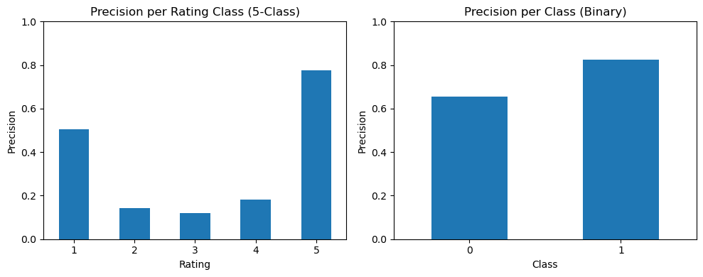

```python
# Classification report for binary model
report_binary = classification_report(
    y_test,
    y_pred_lstm,
    target_names=["0", "1"],
    output_dict=True
)

# Precision values for 5-class model
precision_multi_df = pd.DataFrame({
    "Precision": [
        report_multi["1"]["precision"],
        report_multi["2"]["precision"],
        report_multi["3"]["precision"],
        report_multi["4"]["precision"],
        report_multi["5"]["precision"]
    ]
}, index=["1", "2", "3", "4", "5"])

# Precision values for binary model
precision_binary_df = pd.DataFrame({
    "Precision": [
        report_binary["0"]["precision"],
        report_binary["1"]["precision"]
    ]
}, index=["0", "1"])

# Plot side by side
fig, axes = plt.subplots(1, 2, figsize=(10, 4))

precision_multi_df.plot(kind="bar", ax=axes[0], legend=False)
axes[0].set_title("Precision per Rating Class (5-Class)")
axes[0].set_ylabel("Precision")
axes[0].set_xlabel("Rating")
axes[0].set_ylim(0, 1)
axes[0].tick_params(axis="x", rotation=0)

precision_binary_df.plot(kind="bar", ax=axes[1], legend=False)
axes[1].set_title("Precision per Class (Binary)")
axes[1].set_ylabel("Precision")
axes[1].set_xlabel("Class")
axes[1].set_ylim(0, 1)
axes[1].tick_params(axis="x", rotation=0)

plt.tight_layout()
plt.show()
```

The classification report for the 5-class model shows that the model predominantly predicts the majority class (rating 5), with significantly lower precision and recall for ratings 1–4. This indicates that the model struggles to distinguish between classes and is strongly influenced by the imbalanced distribution of the dataset. As a result, the model fails to learn meaningful patterns for the less frequent rating categories, suggesting that multiclass classification is not well suited for this task.

In contrast, the classification report for the binary model shows more balanced predictions. While recall is lower for class 1, it is substantially higher for class 0, resulting in a higher overall recall. Additionally, both precision and accuracy are significantly improved compared to the multiclass model. Therefore, we choose to proceed with binary classification for the remaining models.

#### Text representation

The textual data must be converted into a numerical format in order to be used by traditional machine learning models. For the traditional models we have chosen, TF-IDF is applied to transform the review text into feature vectors. This allows the model to capture the importance of words relative to the dataset.

We believe that both unigrams and bigrams should be included to capture contextual information. This is particularly useful in sentiment analysis, where phrases such as “not good” carry a different meaning than individual words. This representation enables the models to learn patterns in the text based on word importance and context.

We use a maximum of 5000 features to limit the dimensionality of the data while retaining the most informative terms. English stop words are also removed to eliminate common words that do not contribute meaningful information to the model.

```python
#TD-IDF for all traditional models, the model uses both single (unigrams) words and pairs (biggrams) of words.
vectorizer = TfidfVectorizer(
    max_features=5000,
    ngram_range=(1,2),
    stop_words='english'
)
```

#### Model 2: Multinomial Naive Bayes

MultinomialNB is used as a fast and effective baseline for text classification, particulary suited for sparse count-based features such as TF-IDF. It provides a simple probabilistic approach which provides a clear point of comparison for evaluating more complex models.

```python
# Based on code from GeeksforGeeks
# https://www.geeksforgeeks.org/machine-learning/multinomial-naive-bayes/

# Compute class weights to handle class imbalance
classes = np.unique(y_train)
class_weights_array = compute_class_weight(
    class_weight="balanced",
    classes=classes,
    y=y_train
)


# Convert class weights to dictionary format
class_weights = dict(zip(classes, class_weights_array))
print("Class weights:", class_weights)


# Create sample weights for each training instance
sample_weights = y_train.map(class_weights)

X_train_vec = vectorizer.fit_transform(X_train)
X_test_vec = vectorizer.transform(X_test)

# Train the Naive Bayes model using sample weights
nb_model = MultinomialNB()
nb_model.fit(X_train_vec, y_train, sample_weight=sample_weights)


# Make predictions on the test set
y_pred_nb = nb_model.predict(X_test_vec)

print("Accuracy:", accuracy_score(y_test, y_pred_nb))
print(classification_report(y_test, y_pred_nb))
```

```
Class weights: {np.int64(0): np.float64(1.2711328349626223), np.int64(1): np.float64(0.8241983594332588)}
Accuracy: 0.7649186256781193
              precision    recall  f1-score   support

           0       0.67      0.81      0.73       437
           1       0.86      0.73      0.79       669

    accuracy                           0.76      1106
   macro avg       0.76      0.77      0.76      1106
weighted avg       0.78      0.76      0.77      1106
```

#### Model 3: Logistic Regression

Logistic Regression is included as a strong linear baseline that can capture weighted relationships between features while remaining efficient and interpretable. It is well-suited for high-dimensional TF-IDF representations commonly used in text classification.

```python
# Based on code from w3schools
# https://www.w3schools.com/python/python_ml_logistic_regression.asp

# Train Logistic Regression model with class balancing
log_model = LogisticRegression(max_iter=1000, class_weight="balanced")
log_model.fit(X_train_vec, y_train)


# predict labels for test data
y_pred_log = log_model.predict(X_test_vec)

print("Accuracy:", accuracy_score(y_test, y_pred_log))
print(classification_report(y_test, y_pred_log))
```

```
Accuracy: 0.7459312839059674
              precision    recall  f1-score   support

           0       0.64      0.82      0.72       437
           1       0.86      0.70      0.77       669

    accuracy                           0.75      1106
   macro avg       0.75      0.76      0.74      1106
weighted avg       0.77      0.75      0.75      1106
```

#### Model 4: Linear SVM

Linear SVM is applied as a robust linear classification that performs well high-dimensional spaces and is effective for text classification tasks. It aims to find an optimal separating boundary between classes, often providing strong performance with TF-IDF features.

```python
# Train Linear SVM model with class balancing
svm_model = LinearSVC(class_weight="balanced")
svm_model.fit(X_train_vec, y_train)


# predict labels for test data
y_pred_svm = svm_model.predict(X_test_vec)


print("Accuracy:", accuracy_score(y_test, y_pred_svm))
print(classification_report(y_test, y_pred_svm))
print(confusion_matrix(y_test, y_pred_svm))
```

```
Accuracy: 0.7314647377938517
              precision    recall  f1-score   support

           0       0.64      0.72      0.68       437
           1       0.80      0.74      0.77       669

    accuracy                           0.73      1106
   macro avg       0.72      0.73      0.72      1106
weighted avg       0.74      0.73      0.73      1106

[[313 124]
 [173 496]]
```

### 1.5 Model Comparison

```python
print("\nModel Accuracy Comparison")
print(f"Logistic Regression Accuracy: {accuracy_score(y_test, y_pred_log):.4f}")
print(f"Naive Bayes Accuracy: {accuracy_score(y_test, y_pred_nb):.4f}")
print(f"LSTM Accuracy: {accuracy_score(y_test, y_pred_lstm):.4f}")
print(f"Linear SVM Accuracy: {accuracy_score(y_test, y_pred_svm):.4f}")
```

```
Model Accuracy Comparison
Logistic Regression Accuracy: 0.7459
Naive Bayes Accuracy: 0.7649
LSTM Accuracy: 0.7459
Linear SVM Accuracy: 0.7315
```

The traditional machine learning models use TF-IDF features, while the LSTM model uses tokenized sequences. Due to differences in preprocessing and data splits, the comparison is indicative rather than perfectly equivalent.

#### Accuracy Comparison

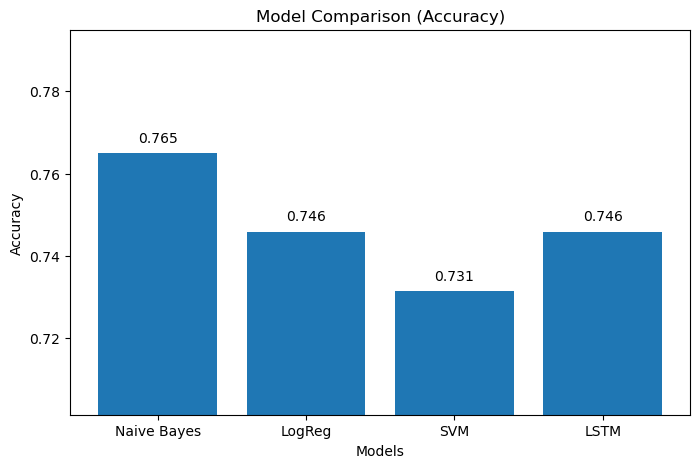

```python
nb_report = classification_report(y_test, y_pred_nb, output_dict=True)
log_report = classification_report(y_test, y_pred_log, output_dict=True)
svm_report = classification_report(y_test, y_pred_svm, output_dict=True)
lstm_report = classification_report(y_test, y_pred_lstm, output_dict=True)

models = ["Naive Bayes", "LogReg", "SVM", "LSTM"]

accuracy_scores = [
    nb_report["accuracy"],
    log_report["accuracy"],
    svm_report["accuracy"],
    lstm_report["accuracy"]
]


# Accuracy graph
plt.figure(figsize=(8, 5))
bars = plt.bar(models, accuracy_scores)

plt.title("Model Comparison (Accuracy)")
plt.xlabel("Models")
plt.ylabel("Accuracy")
plt.ylim(min(accuracy_scores) - 0.03, max(accuracy_scores) + 0.03)

for bar, score in zip(bars, accuracy_scores):
    plt.text(
        bar.get_x() + bar.get_width() / 2,
        bar.get_height() + 0.002,
        f"{score:.3f}",
        ha="center",
        va="bottom"
    )

plt.show()
```

#### F1 score Comparison

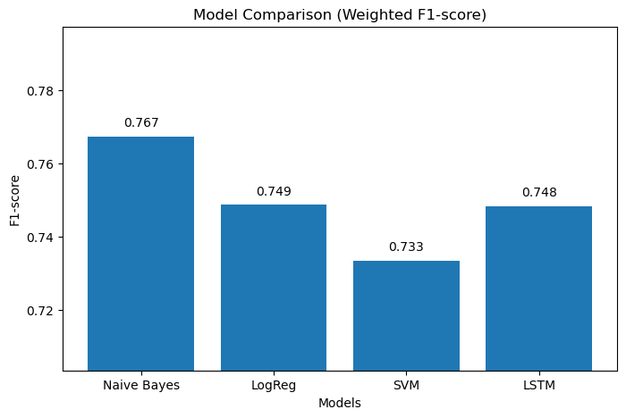

```python
# Weighted F1-score
f1_scores = [
    nb_report["weighted avg"]["f1-score"],
    log_report["weighted avg"]["f1-score"],
    svm_report["weighted avg"]["f1-score"],
    lstm_report["weighted avg"]["f1-score"]
]


# F1-score graph
plt.figure(figsize=(8, 5))
bars = plt.bar(models, f1_scores)

plt.title("Model Comparison (Weighted F1-score)")
plt.xlabel("Models")
plt.ylabel("F1-score")
plt.ylim(min(f1_scores) - 0.03, max(f1_scores) + 0.03)

for bar, score in zip(bars, f1_scores):
    plt.text(
        bar.get_x() + bar.get_width() / 2,
        bar.get_height() + 0.002,
        f"{score:.3f}",
        ha="center",
        va="bottom"
    )

plt.show()
```

#### Precition Comparison

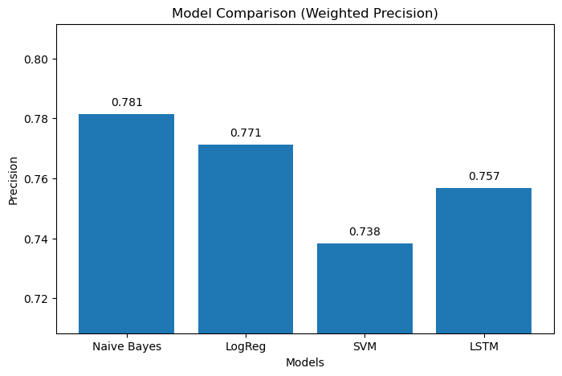

```python
# Weighted precision
precision_scores = [
    nb_report["weighted avg"]["precision"],
    log_report["weighted avg"]["precision"],
    svm_report["weighted avg"]["precision"],
    lstm_report["weighted avg"]["precision"]
]

# Precision graph
plt.figure(figsize=(8, 5))
bars = plt.bar(models, precision_scores)

plt.title("Model Comparison (Weighted Precision)")
plt.xlabel("Models")
plt.ylabel("Precision")
plt.ylim(min(precision_scores) - 0.03, max(precision_scores) + 0.03)

for bar, score in zip(bars, precision_scores):
    plt.text(
        bar.get_x() + bar.get_width() / 2,
        bar.get_height() + 0.002,
        f"{score:.3f}",
        ha="center",
        va="bottom"
    )

plt.show()
```

#### Recall

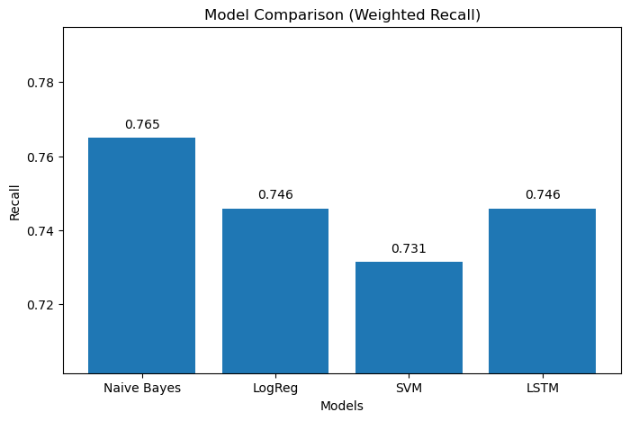

```python
# Weighted recall
recall_scores = [
    nb_report["weighted avg"]["recall"],
    log_report["weighted avg"]["recall"],
    svm_report["weighted avg"]["recall"],
    lstm_report["weighted avg"]["recall"]
]

# Recall graph
plt.figure(figsize=(8, 5))
bars = plt.bar(models, recall_scores)

plt.title("Model Comparison (Weighted Recall)")
plt.xlabel("Models")
plt.ylabel("Recall")
plt.ylim(min(recall_scores) - 0.03, max(recall_scores) + 0.03)

for bar, score in zip(bars, recall_scores):
    plt.text(
        bar.get_x() + bar.get_width() / 2,
        bar.get_height() + 0.002,
        f"{score:.3f}",
        ha="center",
        va="bottom"
    )

plt.show()
```

### 1.6 Analysis of the Results

This difference in performance can be linked to data imbalance, where class 1 contains more observations than class 0, making it easier for the models to learn patterns from the majority class.

In terms of overall performance, Multinomial Naive Bayes achieved the strongest results, followed by Logistic Regression and the LSTM model, while the Linear SVM model performed the weakest.

In conclusion, all models are able to perform the sentiment classification task, but their performance is affected by data imbalance. Multinomial Naive Bayes achieved the best overall performance, while Linear SVM had the lowest. Across all models, class 1 is predicted more accurately than class 0, indicating that the models struggle more with the minority class.

## Task 2

### 2.1 Introduction

The objective of this task is to develop a convolutional neural network (CNN) capable of distinguishing between images created by humans and images generated by artificial intelligence.

### 2.2 Dataset analysis

The dataset consists of two classes:

- AI-generated images
- Human-created images

Based on the dataset size, we hypothesize that the limited amount of data may impact the model’s ability to generalize and could increase the risk of overfitting.

```python
# Counts the number of image files in each folder
base_path = "Art_shuffled"

folders = ["AiArtData", "RealArt"]

image_extensions = (".jpg", ".jpeg", ".png", ".bmp", ".gif", ".webp")

for folder in folders:
    folder_path = os.path.join(base_path, folder)

    count = 0
    for root, dirs, files in os.walk(folder_path): # iterate through files
        count += sum(1 for file in files if file.lower().endswith(image_extensions)) # count images

    print(f"{folder}: {count} pictures")
```

```
AiArtData: 539 pictures
RealArt: 436 pictures
```

The dataset is relatively well balanced. Although there is a slight imbalance toward AI images, we belive it is not significant enough to strongly bias the model. However, it may still introduce a small tendency for the model to favor the majority class.

### 2.3 Methology

In this project, we will test three pretrained CNN models. We will compare these to determine which performs best on the classification task.

The datasets will be split into:

- 80% training data
- 20% validation data

#### Why transfer learning?

Training a deep convolutional neural network from scratch typically requires a large dataset. In this task, the available dataset is relatively limited, making training from scratch impractical. To address this limitation, transfer learning is applied. This approach leverages models pretrained on large-scale datasets. These models have already learned general visual features, including edges, textures, and object structures, which can be reused for new tasks. As a result, transfer learning enables faster convergence and improves generalization performance.

#### Model selection

To determine the most suitable model for our task, we are going to compare several pretrained convolutional neural network architectures: ResNet50, MobileNetV2, and EfficientNetB0. These models were selected because they represent different architectural approaches. ResNet50 is a deep residual network designed for high accuracy, MobileNetV2 is optimized for computational efficiency, and EfficientNetB0 balances accuracy and efficiency. The models are evaluated primarily based on accuracy to determine which approach performs best on the dataset.

#### Model training and Evaluation

```python
# Based on TensorFlow/Keras documentation for image classification
# https://www.tensorflow.org/tutorials/images/classification

# Load image dataset, split into training/validation sets, and optimize data pipeline
IMG_SIZE = (224, 224) # Images resized to 224×224
BATCH_SIZE = 32 # in batches of 32
EPOCHS = 10
SEED = 42

data_dir = "Art_shuffled" # dataset directory

# Load 80% of the images for training
train_ds = image_dataset_from_directory(
    data_dir,
    validation_split=0.2,
    subset="training",
    seed=SEED,
    image_size=IMG_SIZE,
    batch_size=BATCH_SIZE
)

# Load 20% of the images for validation
val_ds = image_dataset_from_directory(
    data_dir,
    validation_split=0.2,
    subset="validation",
    seed=SEED,
    image_size=IMG_SIZE,
    batch_size=BATCH_SIZE
)

class_names = train_ds.class_names
print("Class names:", class_names)

AUTOTUNE = tf.data.AUTOTUNE
train_ds = train_ds.cache().prefetch(buffer_size=AUTOTUNE) # speed up training
val_ds = val_ds.cache().prefetch(buffer_size=AUTOTUNE) # optimize data loading
```

```
Found 962 files belonging to 2 classes.
Using 770 files for training.
Found 962 files belonging to 2 classes.
Using 192 files for validation.
Class names: ['AiArtData', 'RealArt']
```

```python
# Based on TensorFlow/Keras documentation for transfer learning
# https://www.tensorflow.org/tutorials/images/transfer_learning

# Store model results for comparison
results = []

def build_model(base_model_fn, preprocess_fn, name):
    # Load a pretrained CNN without its original classification layer
    base_model = base_model_fn(
        include_top=False,
        weights="imagenet",
        input_shape=(224, 224, 3)
    )
    base_model.trainable = False # freeze pretrained layers, only the new classification layers will be trained

    inputs = keras.Input(shape=(224, 224, 3))
    x = preprocess_fn(inputs) # apply model-specific preprocessing
    x = base_model(x, training=False) # extract features

    # new classification layers
    x = layers.GlobalAveragePooling2D()(x) # reduce spatial dimensions
    x = layers.Dense(256, activation="relu")(x) # fully connected layer
    x = layers.Dropout(0.3)(x) # reduce overfitting
    outputs = layers.Dense(1, activation="sigmoid")(x) # outputs probability for class 1

    model = keras.Model(inputs, outputs, name=name)

    # Compile the model for binary classification
    model.compile(
        optimizer="adam",
        loss="binary_crossentropy",
        metrics=["accuracy"]
    )

    return model
```

##### Early Stopping

To ensure a fair comparison, early stopping will be applied during training of all models.

```python
# Stop training early if validation loss does not improve
early_stopping = EarlyStopping(
    monitor="val_loss",
    patience=2,
    restore_best_weights=True
)
```

##### ResNet50

```python
# Based on TensorFlow/Keras documentation for transfer learning
# https://keras.io/api/applications/resnet/resnet_models/#resnet50-function

print("Training ResNet50...")

# Build model
resnet_model = build_model(ResNet50, resnet_preprocess, "ResNet50")

# Train only the new classification layers
# The pretrained ResNet50 layers are frozen at this stage
resnet_history = resnet_model.fit(
    train_ds,
    validation_data=val_ds,
    epochs=10,  # higher max, will stop early
    verbose=2,
    callbacks=[early_stopping]
)

# Evaluate the model on the validation set
resnet_loss, resnet_acc = resnet_model.evaluate(val_ds, verbose=0)

# Store results
results.append({
    "Model": "ResNet50",
    "Validation Accuracy": resnet_acc
})

print(f"ResNet50 Accuracy: {resnet_acc:.4f}")
```

```
Training ResNet50...
```

```
2026-04-29 15:10:31.265929: W tensorflow/core/lib/png/png_io.cc:95] PNG warning: iCCP: profile 'ICC Profile': 'CMYK': invalid ICC profile color space
2026-04-29 15:10:42.208725: W tensorflow/core/lib/png/png_io.cc:95] PNG warning: iCCP: profile 'ICC Profile': 1000000h: invalid rendering intent
```

```
25/25 - 30s - 1s/step - accuracy: 0.6857 - loss: 0.6808 - val_accuracy: 0.8229 - val_loss: 0.4284
25/25 - 24s - 969ms/step - accuracy: 0.8429 - loss: 0.3681 - val_accuracy: 0.8594 - val_loss: 0.3682
25/25 - 25s - 990ms/step - accuracy: 0.9130 - loss: 0.2414 - val_accuracy: 0.8281 - val_loss: 0.4217
25/25 - 25s - 983ms/step - accuracy: 0.9390 - loss: 0.1726 - val_accuracy: 0.8385 - val_loss: 0.3965
ResNet50 Accuracy: 0.8594
```

##### MobileNetV2

```python
# Based on TensorFlow/Keras documentation for transfer learning
# https://keras.io/api/applications/mobilenet/mobilenet_models/#mobilenetv2-function

print("Training MobileNetV2...")

# Build model
mobilenet_model = build_model(MobileNetV2, mobilenet_preprocess, "MobileNetV2")

# Train model
mobilenet_history = mobilenet_model.fit(
    train_ds,
    validation_data=val_ds,
    epochs=10, # higher max, will stop early
    verbose=2,
    callbacks=[early_stopping]
)

# Evaluate model
mobilenet_loss, mobilenet_acc = mobilenet_model.evaluate(val_ds, verbose=0)

# Store results
results.append({
    "Model": "MobileNetV2",
    "Validation Accuracy": mobilenet_acc
})

print(f"MobileNetV2 Accuracy: {mobilenet_acc:.4f}")
```

```
Training MobileNetV2...
25/25 - 8s - 307ms/step - accuracy: 0.6623 - loss: 0.6309 - val_accuracy: 0.7969 - val_loss: 0.4729
25/25 - 6s - 249ms/step - accuracy: 0.8403 - loss: 0.3543 - val_accuracy: 0.7917 - val_loss: 0.4811
MobileNetV2 Accuracy: 0.7969
```

##### EfficientNetB0

```python
# Based on TensorFlow/Keras documentation for transfer learning
# https://keras.io/api/applications/efficientnet/efficientnet_models/#efficientnetb0-function

print("Training EfficientNetB0...")

# Build model
efficientnet_model = build_model(EfficientNetB0, efficientnet_preprocess, "EfficientNetB0")

# Train model
efficientnet_history = efficientnet_model.fit(
    train_ds,
    validation_data=val_ds,
    epochs=10,
    verbose=2,
    callbacks=[early_stopping]
)

# Store results
efficientnet_loss, efficientnet_acc = efficientnet_model.evaluate(val_ds, verbose=0)

# Store results
results.append({
    "Model": "EfficientNetB0",
    "Validation Accuracy": efficientnet_acc
})

print(f"EfficientNetB0 Accuracy: {efficientnet_acc:.4f}")
```

```
Training EfficientNetB0...
25/25 - 16s - 632ms/step - accuracy: 0.7013 - loss: 0.5680 - val_accuracy: 0.8490 - val_loss: 0.4487
25/25 - 11s - 438ms/step - accuracy: 0.8662 - loss: 0.3269 - val_accuracy: 0.8750 - val_loss: 0.4002
EfficientNetB0 Accuracy: 0.8490
```

##### Model Comparison

```python
comparison_df = pd.DataFrame(results)

comparison_df = comparison_df.sort_values(
    by="Validation Accuracy", ascending=False
).reset_index(drop=True)

comparison_df["Validation Accuracy"] = comparison_df["Validation Accuracy"].round(4)

comparison_df
```

|  | Model | Validation Accuracy |
| --- | --- | --- |
| 0 | ResNet50 | 0.8594 |
| 1 | EfficientNetB0 | 0.8490 |
| 2 | MobileNetV2 | 0.7969 |

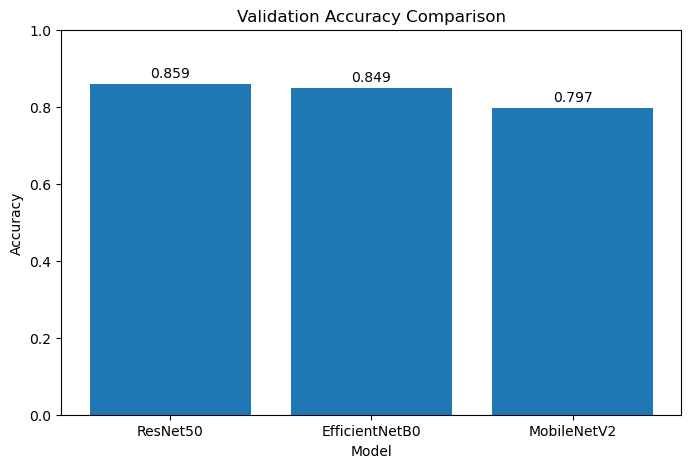

```python
comparison_df = pd.DataFrame(results)

comparison_df = comparison_df.sort_values(
    by="Validation Accuracy", ascending=False
).reset_index(drop=True)

comparison_df["Validation Accuracy"] = comparison_df["Validation Accuracy"].round(4)

plt.figure(figsize=(8, 5))
bars = plt.bar(comparison_df["Model"], comparison_df["Validation Accuracy"])

plt.title("Validation Accuracy Comparison")
plt.xlabel("Model")
plt.ylabel("Accuracy")
plt.ylim(0, 1)

for bar in bars:
    height = bar.get_height()
    plt.text(
        bar.get_x() + bar.get_width() / 2,
        height + 0.01,
        f"{height:.3f}",
        ha="center",
        va="bottom"
    )

plt.show()
```

Based on the results, ResNet50 is selected as the final model since it achieved the highest validation accuracy among the evaluated models. Although MobileNetV2 trained significantly faster, ResNet50 provided better classification performance, which was prioritized for this task.

### 2.4 Model Architecture

A visualization of the architecture is included below.

```python
resnet_model.summary()
```

```
Model: "ResNet50"
```

```
┏━━━━━━━━━━━━━━━━━━━━━┳━━━━━━━━━━━━━━━━━━━┳━━━━━━━━━━━━┳━━━━━━━━━━━━━━━━━━━┓
┃ Layer (type)        ┃ Output Shape      ┃    Param # ┃ Connected to      ┃
┡━━━━━━━━━━━━━━━━━━━━━╇━━━━━━━━━━━━━━━━━━━╇━━━━━━━━━━━━╇━━━━━━━━━━━━━━━━━━━┩
│ input_layer_52      │ (None, 224, 224,  │          0 │ -                 │
│ (InputLayer)        │ 3)                │            │                   │
├─────────────────────┼───────────────────┼────────────┼───────────────────┤
│ get_item_24         │ (None, 224, 224)  │          0 │ input_layer_52[0… │
│ (GetItem)           │                   │            │                   │
├─────────────────────┼───────────────────┼────────────┼───────────────────┤
│ get_item_25         │ (None, 224, 224)  │          0 │ input_layer_52[0… │
│ (GetItem)           │                   │            │                   │
├─────────────────────┼───────────────────┼────────────┼───────────────────┤
│ get_item_26         │ (None, 224, 224)  │          0 │ input_layer_52[0… │
│ (GetItem)           │                   │            │                   │
├─────────────────────┼───────────────────┼────────────┼───────────────────┤
│ stack_8 (Stack)     │ (None, 224, 224,  │          0 │ get_item_24[0][0… │
│                     │ 3)                │            │ get_item_25[0][0… │
│                     │                   │            │ get_item_26[0][0] │
├─────────────────────┼───────────────────┼────────────┼───────────────────┤
│ add_8 (Add)         │ (None, 224, 224,  │          0 │ stack_8[0][0]     │
│                     │ 3)                │            │                   │
├─────────────────────┼───────────────────┼────────────┼───────────────────┤
│ resnet50            │ (None, 7, 7,      │ 23,587,712 │ add_8[0][0]       │
│ (Functional)        │ 2048)             │            │                   │
├─────────────────────┼───────────────────┼────────────┼───────────────────┤
│ global_average_poo… │ (None, 2048)      │          0 │ resnet50[0][0]    │
│ (GlobalAveragePool… │                   │            │                   │
├─────────────────────┼───────────────────┼────────────┼───────────────────┤
│ dense_60 (Dense)    │ (None, 256)       │    524,544 │ global_average_p… │
├─────────────────────┼───────────────────┼────────────┼───────────────────┤
│ dropout_39          │ (None, 256)       │          0 │ dense_60[0][0]    │
│ (Dropout)           │                   │            │                   │
├─────────────────────┼───────────────────┼────────────┼───────────────────┤
│ dense_61 (Dense)    │ (None, 1)         │        257 │ dropout_39[0][0]  │
└─────────────────────┴───────────────────┴────────────┴───────────────────┘
```

```
 Total params: 25,162,117 (95.99 MB)
```

```
 Trainable params: 524,801 (2.00 MB)
```

```
 Non-trainable params: 23,587,712 (89.98 MB)
```

```
 Optimizer params: 1,049,604 (4.00 MB)
```

### Finetuning ResNet50

```python
# Based on TensorFlow/Keras documentation for transfer learning
# https://www.tensorflow.org/tutorials/images/transfer_learning

print("Finetuning ResNet50...")

base_model = resnet_model.get_layer("resnet50")
base_model.trainable = True # Unfreeze the base model to enable finetuning

# Freeze most of the layers and only train the last layers
# This allows the model to adapt high-level features without destroying learned low-level features
for layer in base_model.layers[:-20]:
    layer.trainable = False

# Recompile the model with a low learning rate, to avoid large updates to pretrained weights
resnet_model.compile(
    optimizer=keras.optimizers.Adam(learning_rate=1e-5),
    loss="binary_crossentropy",
    metrics=["accuracy"]
)

# Updated both the custom head and the last layers of ResNet50
resnet_finetune_history = resnet_model.fit(
    train_ds,
    validation_data=val_ds,
    epochs=5,
    verbose=2,
    callbacks=[early_stopping]
)

finetuned_loss, finetuned_acc = resnet_model.evaluate(val_ds, verbose=0)

print(f"Finetuned Accuracy: {finetuned_acc:.4f}")
```

```
Finetuning ResNet50...
25/25 - 45s - 2s/step - accuracy: 0.8961 - loss: 0.2593 - val_accuracy: 0.8646 - val_loss: 0.3591
25/25 - 40s - 2s/step - accuracy: 0.9429 - loss: 0.2067 - val_accuracy: 0.8646 - val_loss: 0.3508
25/25 - 41s - 2s/step - accuracy: 0.9636 - loss: 0.1647 - val_accuracy: 0.8646 - val_loss: 0.3468
25/25 - 48s - 2s/step - accuracy: 0.9831 - loss: 0.1330 - val_accuracy: 0.8646 - val_loss: 0.3435
25/25 - 41s - 2s/step - accuracy: 0.9805 - loss: 0.1130 - val_accuracy: 0.8594 - val_loss: 0.3441
Finetuned Accuracy: 0.8646
```

The model was first trained with frozen pretrained layers. Then, the last layers were unfrozen and trained again with a lower learning rate to improve performance.

#### Comparing before and after finetuning

Finetuning resulted in a slight improvement in validation accuracy. This indicates that allowing the deeper layers of the network to adapt to the dataset provided additional performance gains. The improvement is relatively small, which is expected since the pretrained model already captures strong general features.

### 2.5 Results

#### Training and Validation Curves

To evaluate the training process, we will plot training accuracy vs validation accuracy and training loss vs validation loss. These curves can help identify whether the model is learning well or overfitting.

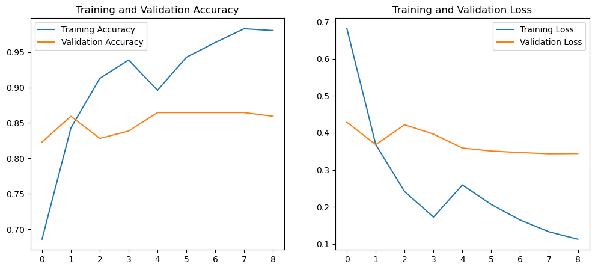

```python
acc = resnet_history.history['accuracy'] + resnet_finetune_history.history['accuracy']
val_acc = resnet_history.history['val_accuracy'] + resnet_finetune_history.history['val_accuracy']

loss = resnet_history.history['loss'] + resnet_finetune_history.history['loss']
val_loss = resnet_history.history['val_loss'] + resnet_finetune_history.history['val_loss']

epochs_range = range(len(acc))

plt.figure(figsize=(12, 5))

plt.subplot(1, 2, 1)
plt.plot(epochs_range, acc, label="Training Accuracy")
plt.plot(epochs_range, val_acc, label="Validation Accuracy")
plt.title("Training and Validation Accuracy")
plt.legend()

plt.subplot(1, 2, 2)
plt.plot(epochs_range, loss, label="Training Loss")
plt.plot(epochs_range, val_loss, label="Validation Loss")
plt.title("Training and Validation Loss")
plt.legend()

plt.show()
```

The model achieves higher accuracy on the training data than on the validation data. The continued improvement in training performance, combined with a noticeable gap compared to validation performance, indicates a degree of overfitting.

This is further supported by the loss curves. While the training loss steadily decreases, the validation loss stabilizes in later epochs. This suggests that the model is becoming more specialized to the training data. However, the validation performance remains relatively stable, indicating that the model still generalizes reasonably well to unseen data.

### Evaluation on Validation Set

The model is evaluated on validation data set to measure overall performance. In addition to loss and accuracy, we also compute a confusion matrix and a classification report. These metrics can give a clearer picture of how the model performs on each class.

```python
y_pred_probs = resnet_model.predict(val_ds, verbose=0).flatten() # predicted probabilities
y_pred = (y_pred_probs > 0.5).astype(int) # convert to binary labels

y_true = np.concatenate([y.numpy() for x, y in val_ds], axis=0)  # extract true labels

cm = confusion_matrix(y_true, y_pred)
print("Confusion Matrix:")
print(cm)

print("\nClassification Report:")
print(classification_report(y_true, y_pred, target_names=class_names)) # precision, recall, F1
```

```
Confusion Matrix:
[[94 13]
 [13 72]]

Classification Report:
              precision    recall  f1-score   support

   AiArtData       0.88      0.88      0.88       107
     RealArt       0.85      0.85      0.85        85

    accuracy                           0.86       192
   macro avg       0.86      0.86      0.86       192
weighted avg       0.86      0.86      0.86       192
```

Although the confusion matrix and classification report show relatively good performance, the training curves, discussed earlier, indicate clear signs of overfitting. The model achieves much higher accuracy on the training data than on the validation data, suggesting that it does not generalize optimally to unseen data. Good performance does not necessarily imply good generalization.

### 2.6. Discussion

#### Limitations

Finally, the evaluation based on a relatively small validation set may introduce variability in the results, making performance estimates less stable.

### 2.7 Test on Unseen Images

[figure not shown]

```
ai_art1.png: AI-generated (77.25%)
```

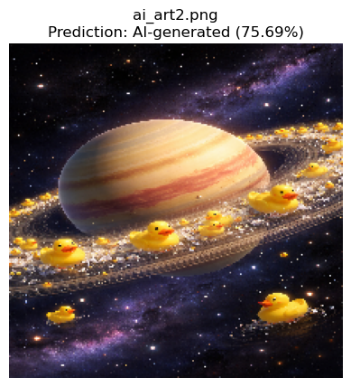

```
ai_art2.png: AI-generated (75.69%)
```

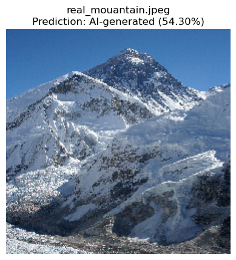

```
real_mouantain.jpeg: AI-generated (54.30%)
```

[figure not shown]

```
real_skrik.jpg: Human-created (78.67%)
```

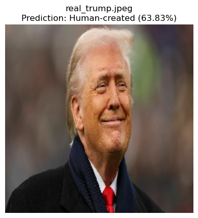

```
real_trump.jpeg: Human-created (63.83%)
```

```python
test_dir = "test_images"

test_results = []

for img_name in sorted(os.listdir(test_dir)):

    img_path = os.path.join(test_dir, img_name)

    img = image.load_img(img_path, target_size=(224,224))  # load and resize image
    img_array = image.img_to_array(img) # convert to array
    img_array = np.expand_dims(img_array, axis=0) # add batch dimension


    prediction = resnet_model.predict(img_array, verbose=0)[0][0] # predicted probability

    if prediction > 0.5:
        label = "Human-created"
        confidence = prediction
    else:
        label = "AI-generated"
        confidence = 1 - prediction

    test_results.append((img_name, label, confidence)) # store results

    plt.imshow(img)
    plt.title(f"{img_name}\nPrediction: {label} ({confidence:.2%})")
    plt.axis("off")
    plt.show()

    print(f"{img_name}: {label} ({confidence:.2%})")
```

### 2.8 Analysis of the results

The results indicate that the model struggles to generalize beyond the training data, as reflected in both incorrect predictions and low confidence scores. This suggests that the dataset may not be diverse enough for the model to learn robust and generalizable features. Overall, this highlights the importance of larger and more varied datasets when training deep learning models, as well as the need for stronger regularization techniques to improve performance on unseen data. These findings demonstrate that high validation accuracy does not necessarily translate to strong real-world performance.

## Sources

GeeksforGeeks. “Long Shortterm Memory (LSTM) RNN in Tensorflow.” GeeksforGeeks, 8 Jan. 2023, www.geeksforgeeks.org/deep-learning/long-short-term-memory-lstm-rnn-in-tensorflow/.

GeeksforGeeks. “Long Shortterm Memory (LSTM) RNN in Tensorflow.” GeeksforGeeks, 8 Jan. 2023, www.geeksforgeeks.org/deep-learning/long-short-term-memory-lstm-rnn-in-tensorflow/.

GeeksforGeeks. “Multinomial Naive Bayes.” GeeksforGeeks, 17 Nov. 2023, www.geeksforgeeks.org/machine-learning/multinomial-naive-bayes/.

Team, Keras. “Keras Documentation: EfficientNet Models.” Keras.io, 2019, keras.io/api/applications/efficientnet/efficientnet_models/#efficientnetb0-function. Accessed 28 Apr. 2026.

Team, Keras. “Keras Documentation: MobileNet Models.” Keras.io, 2018, keras.io/api/applications/mobilenet/mobilenet_models/#mobilenetv2-function.

TensorFlow. “Image Classification | TensorFlow Core.” TensorFlow, www.tensorflow.org/tutorials/images/classification.

“Transfer Learning with a Pretrained ConvNet | TensorFlow Core.” TensorFlow, www.tensorflow.org/tutorials/images/transfer_learning.

w3schools. “Python Machine Learning - Logistic Regression.” Www.w3schools.com, www.w3schools.com/python/python_ml_logistic_regression.asp.

“Welcome to Zscaler Directory Authentication.” Keras.io, 2026, keras.io/api/applications/resnet/resnet_models/#resnet50-function.